# Working with Data in R

March 4, 2015

Most of this material can be found at:

http://cran.rstudio.com/web/packages/dplyr/vignettes/introduction.html

## Welcome to R

> Whenever you're learning a new tool, for a long time you're going to suck … but the good news is that is typical, that's something that happens to everyone, and it's only temporary.

-Hadley Wickham

## Welcome to R

- New users: go to `rstudio.mtholyoke.edu` and enter your campus login info.
- Experienced users: either login to the server or bring up R/RStudio on your laptop.

## Part I: Getting the data

## What does a data set *look like*?

- **Observations** down the rows
- **Variables** across the columns
- Flat file versus relational database.

## Reading in data from a file

Hosted online:

```r
LAhomes <- read.csv("http://andrewpbray.github.io/data/LA.csv")
```

Hosted locally:

```r
LAhomes <- read.csv("LA.csv")
```

Things to note:

- The assign arrow is used to create **objects** in R, which are stored in your environment.
- Object names don't have to correspond to file names.
- Be sure R knows where to look for the file!

## Viewing data - the viewer

- `View()` can be used in RStudio to bring up an excel-style spreadsheet. Only for viewing, not editing!
- The dimensions of the data can be found in the environment pane.
- The names of the variables can be seen at the top of the viewer.

## Viewing data - the console

- `head()` can be used to print the first several lines of the dataset to the console.
- `dim()` can be used to find the dimensions (rows then columns).
- `names()` can be used to find the names of the variables.
- DANGER ZONE : don't type the name of the data set at the console and hit enter! : DANGER ZONE

## Your turn

There is a data set called `poverty.txt` in the same website directory as `LA.csv`. Please download that file to your machine (upload to the server) and read it in.

Running in to problems? Ask your neighbor or try google!

1. What are the dimensions of the data set?
2. What appears to be the unit of observation?
3. What are the variables?

```r
poverty <- read.table("poverty.txt")
dim(poverty)
head(poverty)
names(poverty)
```

## Reading in data from a package

1. Download and install the package from CRAN (on a non-server version).

   ```r
   install.packages("nycflights13")
   ```

2. Load the package.

   ```r
   library(nycflights13)
   ```

3. Make the data set visible.

   ```r
   data(flights)
   ```

4. Get help.

   ```r
   ?flights
   ```

## Part II: Slice and dice with dplyr

## Why dplyr?

Data sets are often of high *volume* (lots of rows) and high *variety* (lots of columns). This is overwhelming to visualize and analyze, so we find ourselves chopping the data set up into more manageable and meaningful chunks. We also often need to perform operations to organize and clean our data.

This is all possible in base R, but with `dplyr`, it is simple, readible, and fast.

## The Seven Verbs

- filter
- arrange
- select
- distinct
- mutate
- summarise
- sample_n

## filter()

Allows you to select a subset of the **rows** of a data frame. The first argument is the name of the data frame, the following arguments are the filters that you'd like to apply

For all flights on January 1st:

```r
library(dplyr)
filter(flights, month == 1, day == 1)
```

```
## Source: local data frame [842 x 16]
##
##    year month day dep_time dep_delay arr_time arr_delay carrier tailnum
## 1  2013     1   1      517         2      830        11      UA  N14228
## 2  2013     1   1      533         4      850        20      UA  N24211
## 3  2013     1   1      542         2      923        33      AA  N619AA
## 4  2013     1   1      544        -1     1004       -18      B6  N804JB
## 5  2013     1   1      554        -6      812       -25      DL  N668DN
## 6  2013     1   1      554        -4      740        12      UA  N39463
## 7  2013     1   1      555        -5      913        19      B6  N516JB
## 8  2013     1   1      557        -3      709       -14      EV  N829AS
## 9  2013     1   1      557        -3      838        -8      B6  N593JB
## 10 2013     1   1      558        -2      753         8      AA  N3ALAA
## ..  ...   ... ...      ...       ...      ...       ...     ...     ...
## Variables not shown: flight (int), origin (chr), dest (chr), air_time
##   (dbl), distance (dbl), hour (dbl), minute (dbl)
```

## Constructing filters

Filters are constructed of **logical operators**: `<`, `>`, `<=`, `>=`, `==`, `!=` (and some others).

Adding them one by one to `filter()` is akin to saying "this AND that". To say "this OR that OR both", use |.

```r
filter(flights, month == 1 | month == 2)
```

```
## Source: local data frame [51,955 x 16]
##
##    year month day dep_time dep_delay arr_time arr_delay carrier tailnum
## 1  2013     1   1      517         2      830        11      UA  N14228
## 2  2013     1   1      533         4      850        20      UA  N24211
## 3  2013     1   1      542         2      923        33      AA  N619AA
## 4  2013     1   1      544        -1     1004       -18      B6  N804JB
## 5  2013     1   1      554        -6      812       -25      DL  N668DN
## 6  2013     1   1      554        -4      740        12      UA  N39463
## 7  2013     1   1      555        -5      913        19      B6  N516JB
## 8  2013     1   1      557        -3      709       -14      EV  N829AS
## 9  2013     1   1      557        -3      838        -8      B6  N593JB
## 10 2013     1   1      558        -2      753         8      AA  N3ALAA
## ..  ...   ... ...      ...       ...      ...       ...     ...     ...
## Variables not shown: flight (int), origin (chr), dest (chr), air_time
##   (dbl), distance (dbl), hour (dbl), minute (dbl)
```

## Your turn

Construct filters to isolate:

```r
filter(flights, month == 3, day == 17)
filter(flights, dest == "ORD")
filter(flights, dest == "ORD", carrier == "UA")
filter(flights, distance > 2000 | air_time > 5*60)
```

## arrange()

`arrange()` works similarly to `filter()` except that instead of filtering or selecting rows, it reorders them. It takes a data frame, and a set of column names (or more complicated expressions) to order by. If you provide more than one column name, each additional column will be used to break ties in the values of preceding columns:

```r
arrange(flights, year, month, day)
```

Use `desc()` to sort in descending order.

```r
arrange(flights, desc(arr_delay))
```

## select()

Often you work with large datasets with many columns where only a few are actually of interest to you. `select()` allows you to rapidly zoom in on a useful subset using operations that usually only work on numeric variable positions:

```r
select(flights, year, month, day)
```

You can exclude columns using `-` and specify a range using `:`.

```r
select(flights, -(year:day))
```

## distinct()

A common use of `select()` is to find out which values a set of variables takes. This is particularly useful in conjunction with the `distinct()` verb which only returns the unique values in a table.

What do the following data correspond to?

```r
distinct(select(flights, origin, dest))
```

```
## Source: local data frame [224 x 2]
##
##    origin dest
## 1     EWR  IAH
## 2     LGA  IAH
## 3     JFK  MIA
## 4     JFK  BQN
## 5     LGA  ATL
## 6     EWR  ORD
## 7     EWR  FLL
## 8     LGA  IAD
## 9     JFK  MCO
## 10    LGA  ORD
## ..    ...  ...
```

## mutate()

As well as selecting from the set of existing columns, it's often useful to add new columns that are functions of existing columns. This is the job of `mutate()`:

```r
mutate(flights, gain = arr_delay - dep_delay)
```

```
## Source: local data frame [336,776 x 17]
##
##    year month day dep_time dep_delay arr_time arr_delay carrier tailnum
## 1  2013     1   1      517         2      830        11      UA  N14228
## 2  2013     1   1      533         4      850        20      UA  N24211
## 3  2013     1   1      542         2      923        33      AA  N619AA
## 4  2013     1   1      544        -1     1004       -18      B6  N804JB
## 5  2013     1   1      554        -6      812       -25      DL  N668DN
## 6  2013     1   1      554        -4      740        12      UA  N39463
## 7  2013     1   1      555        -5      913        19      B6  N516JB
## 8  2013     1   1      557        -3      709       -14      EV  N829AS
## 9  2013     1   1      557        -3      838        -8      B6  N593JB
## 10 2013     1   1      558        -2      753         8      AA  N3ALAA
## ..  ...   ... ...      ...       ...      ...       ...     ...     ...
## Variables not shown: flight (int), origin (chr), dest (chr), air_time
##   (dbl), distance (dbl), hour (dbl), minute (dbl), gain (dbl)
```

## summarise() and sample_n()

`summarise()` collapses a data frame to a single row. It's not very useful yet. `sample_n()` provides you with a random sample of the rows.

```r
summarise(flights, delay = mean(dep_delay, na.rm = TRUE))
```

```
## Source: local data frame [1 x 1]
##
##      delay
## 1 12.63907
```

```r
sample_n(flights, 10)
```

```
## Source: local data frame [10 x 16]
##
##    year month day dep_time dep_delay arr_time arr_delay carrier tailnum
## 1  2013    10  29      808        -7     1050       -33      B6  N373JB
## 2  2013    12   8     1808        39     2140        71      UA  N48127
## 3  2013    12  29      838        -4     1138        -3      B6  N509JB
## 4  2013    10  24     1003         3     1300        -6      UA  N79279
## 5  2013     3  30     1103       -12     1428         3      AA  N3JMAA
## 6  2013    12  22     2322       156      235       157      B6  N652JB
## 7  2013     1  14     2219        20     2313         7      EV  N13992
## 8  2013     6   7       NA        NA       NA        NA      MQ  N711MQ
## 9  2013     4   3      602        -3      733        -2      MQ  N738MQ
## 10 2013     5   7      746        -9      922       -43      9E  N916XJ
## Variables not shown: flight (int), origin (chr), dest (chr), air_time
##   (dbl), distance (dbl), hour (dbl), minute (dbl)
```

## Your turn

**Mutate** the data into a new variable that contains the average speed traveled by the plane for each flight. **Select** that new variable and save it, along with tailnum, as a new dataframe object.

## Your turn

```r
flights2 <- mutate(flights, speed = distance/(air_time/60))
speed <- select(flights2, tailnum, speed)
```

## Aggregation aka group_by()

These verbs become really powerful when you combine them with the idea of "group by", repeating the operation individually on groups of observations within the dataset. The `group_by()` function describes how to break a dataset down into groups of rows.

You can then use the resulting object in exactly the same functions as above; they'll automatically work "by group" when the input is a grouped.

## group_by()

We can find the fastest airplanes in the bunch:

```r
by_tailnum <- group_by(speed, tailnum)
avg_speed <- summarise(by_tailnum,
                       count = n(),
                       avg_speed = mean(speed, na.rm = TRUE))
arrange(avg_speed, desc(avg_speed))
```

```
## Source: local data frame [4,044 x 3]
##
##    tailnum count avg_speed
## 1   N228UA     1  500.8163
## 2   N315AS     1  498.6851
## 3   N654UA     1  498.5821
## 4   N819AW     1  490.3448
## 5   N382HA    26  485.6026
## 6   N388HA    36  484.3891
## 7   N391HA    21  484.0645
## 8   N777UA     1  483.3645
## 9   N385HA    28  482.8947
## 10  N392HA    13  482.2468
## ..     ...   ...       ...
```

## Chaining

Instead of applying each verb step-by-step, we can chain them into a single data pipeline, connected with the `%>%` operator. You start the pipeline with a dataframe and then pass it to each function in turn.

```r
speed %>%
  group_by(tailnum) %>%
  summarise(count = n(), avg_speed = mean(speed, na.rm = TRUE)) %>%
  arrange(desc(avg_speed))
```

```
## Source: local data frame [4,044 x 3]
##
##    tailnum count avg_speed
## 1   N228UA     1  500.8163
## 2   N315AS     1  498.6851
## 3   N654UA     1  498.5821
## 4   N819AW     1  490.3448
## 5   N382HA    26  485.6026
## 6   N388HA    36  484.3891
## 7   N391HA    21  484.0645
## 8   N777UA     1  483.3645
## 9   N385HA    28  482.8947
## 10  N392HA    13  482.2468
## ..     ...   ...       ...
```

## Your turn

Form a chain that creates a data frame containing only carrier and their mean departure delay time. Which carriers have the highest and lowest mean delays?

## Your turn

```r
flights %>%
  group_by(carrier) %>%
  summarise(avg_delay = mean(dep_delay, na.rm = TRUE)) %>%
  arrange(desc(avg_delay))
```

```
## Source: local data frame [16 x 2]
##
##    carrier avg_delay
## 1       F9 20.215543
## 2       EV 19.955390
## 3       YV 18.996330
## 4       FL 18.726075
## 5       WN 17.711744
## 6       9E 16.725769
## 7       B6 13.022522
## 8       VX 12.869421
## 9       OO 12.586207
## 10      UA 12.106073
## 11      MQ 10.552041
## 12      DL  9.264505
## 13      AA  8.586016
## 14      AS  5.804775
## 15      HA  4.900585
## 16      US  3.782418
```

## Your turn again

Say you're curious about the relationship between the number of flights each plane made in 2013, the mean distance that each of those planes flew, and the mean arrival delay. You also want to exclude the edge cases from your analysis, so focus on the planes that have logged more than 20 flights and flown an average distance of less than 2000 miles. Please form the chain that creates this dataset.

## Your turn again

```r
delay <- flights %>%
  group_by(tailnum) %>%
  summarise(count = n(),
            dist = mean(distance, na.rm = TRUE),
            delay = mean(arr_delay, na.rm = TRUE)) %>%
  filter(count > 20, dist < 2000)
```

## Visualizing the data

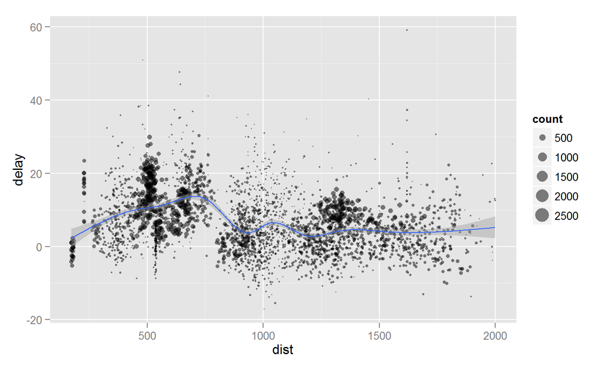